# Importação de Dados Locais

Análise de Dados Financeiros e Econômicos com o R

Marcelo S. Perlin

EA-UFRGS

27/08/2026

# Importação de dados locais no R

## Formatos disponíveis

> Dados são serializados ou salvos em texto em diferentes tipos de arquivos.

Em ordem de popularidade:

- Dados delimitados em texto (*csv*, *tsv*);
- Planilhas do Microsoft Excel (*xls*, *xlsx*);
- Arquivos de dados nativos do R (*RData* e *rds*)
- SQLite (*SQLITE*) e outros bancos de dados
- Texto não estruturado (*txt*)
- Formato [parquet](https://arrow.apache.org/docs/2.0/r/articles/dataset.html)
- Formato `fst` (*fst*)
- Outros notáveis: [Feather](https://posit.co/blog/feather/)

## Pontos importantes

- o local do arquivo no sistema deve ser indicado explicitamente no código. **Use o autocomplete com tecla *tab***

```r
my_file <- 'C:/Data/MyData.csv'
```

- Note o uso de barras (`/`) para designar o diretório do arquivo. Referências relativas também funcionam, tal como em:

```r
my_file <- 'Data/MyData.csv'
```

- os dados serão importados e exportados no R como **objetos do tipo `dataframe`**.

## Pacote `afedR3`

> Pacote `afedR3` (Perlin 2023) é o pacote oficial do livro, contendo diversos arquivos de dados de exemplo.

Passos:

1. Instale o pacote `remotes` (caso ainda não o tenha feito) e depois instale `afedR3` com comando `remotes::install_github("msperlin/afedR3")`
2. Após instalação, verifique os dados disponíveis com o comando abaixo:

```r
afedR3::data_list()
```

- Para ter o caminho completo de cada arquivo, basta usar função `afedR3::data_path` tendo o nome do arquivo como entrada:

```r
# get location of file
my_f <- afedR3::data_path('CH11_grunfeld.csv')

# print it
print(my_f)
```

```
/home/msperlin/R/x86_64-pc-linux-gnu-library/4.6/afedR3/extdata/data/CH11_grunfeld.csv
```

# Arquivos *csv*

## Introdução

- formato mais popular em análise de dados
- arquivos texto que podem ser abertos por qualquer editor/plataforma
- comportam dados volumosos e podem ser facilmente compactados para .zip ou .tar.gz
- funciona apenas para objetos do tipo `dataframes`
- a importação pode ser problemática, dependendo de onde o arquivo é gerado

## Argumentos da função `readr::read_csv`

```r
help("read_csv", package = 'readr')
```

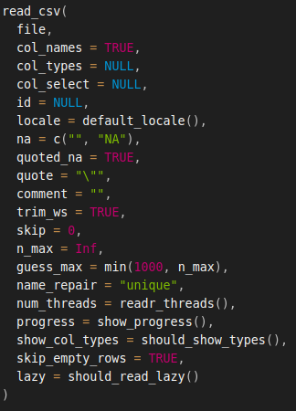

## Importação

```r
# get location of file
my_f <- afedR3::data_path('CH04_ibovespa.csv')

df <- readr::read_csv(my_f)
print(df)
```

```
# A tibble: 3,215 × 2
   ref_date   price_close
   <date>           <dbl>
 1 2010-01-04       70045
 2 2010-01-05       70240
 3 2010-01-06       70729
 4 2010-01-07       70451
 5 2010-01-08       70263
 6 2010-01-11       70433
 7 2010-01-12       70076
 8 2010-01-13       70385
 9 2010-01-14       69801
10 2010-01-15       68978
# ℹ 3,205 more rows
```

## Algumas dicas para lidar com csv

1. Verifique a existência de texto antes dos dados e a necessidade de ignorar algumas linhas iniciais.
2. Verifique a existência ou não dos nomes das colunas na primeira linha com os dados.
3. Verifique qual o símbolo de separador de colunas. Comumente, seguindo notação internacional, será a vírgula, porém nunca se tem certeza sem checar;
4. Para dados numéricos, verifique o símbolo de decimal, o qual deve ser o ponto (`.`) tal como em `2.5`. Caso necessário, podes ajustar o símbolo na própria função de leitura;
5. Verifique a codificação do arquivo de texto (UTF-8, Latin1 (ISO-8859) ou windows1252) e ajuste o código de importação para sincronizar a codificação.
6. **Nunca modifique dados brutos manualmente**. Sempre que você encontrar uma estrutura de texto inesperada em um arquivo *.csv*, use os argumentos da função de leitura *csv* para importar as informações corretamente.

## Um arquivo problemático (1/2)

Agora, vamos estudar um caso mais anormal de arquivo *.csv*. No pacote do livro temos um arquivo chamado `CH04_funky-csv-file.csv` onde:

- o cabeçalho possui texto com informações dos dados;
- o arquivo usará a vírgula como decimal;
- o texto do arquivo conterá caracteres latinos.

As primeiras 10 linhas dos arquivos contém o seguinte conteúdo:

```r
my_f <- afedR3::data_path('CH04_funky-csv-file.csv')

readr::read_lines(my_f, n_max = 10)
```

```
 [1] "Example of funky file:"
 [2] "- columns separated by \";\""
 [3] "- decimal points as \",\""
 [4] ""
 [5] "Data build in 2022-12-28"
 [6] "Origin: www.funkysite.com.br"
 [7] ""
 [8] "ID;Race;Age;Sex;Hour;IQ;Height;Died"
 [9] "001;White;80;Male;00:00:00;92;68;FALSE"
[10] "002;Hispanic;25;Female;00:00:00;99;68;TRUE"
```

## Um arquivo problemático (2/2)

```r
my_locale <- readr::locale(decimal_mark = ',')

df_not_funky <- readr::read_delim(
  file = my_f,
  skip = 7, # how many lines do skip
  delim = ';', # column separator
  col_types = readr::cols(), # column types
  locale = my_locale # locale
)

dplyr::glimpse(df_not_funky)
```

```
Rows: 100
Columns: 8
$ ID     <chr> "001", "002", "003", "004", "005", "006", "007", "008", "009", …
$ Race   <chr> "White", "Hispanic", "Asian", "White", "White", "White", "White…
$ Age    <dbl> 80, 25, 25, 64, 76, 89, 33, 61, 23, 59, 80, 31, 83, 68, 67, 60,…
$ Sex    <chr> "Male", "Female", "Male", "Male", "Female", "Female", "Female",…
$ Hour   <time> 00:00:00, 00:00:00, 00:00:00, 00:00:00, 00:30:00, 00:30:00, 00…
$ IQ     <dbl> 92, 99, 98, 105, 109, 84, 109, 109, 99, 126, 97, 88, 86, 99, 11…
$ Height <dbl> 68, 68, 69, 69, 67, 73, 65, 72, 70, 66, 63, 68, 72, 76, 68, 65,…
$ Died   <lgl> FALSE, TRUE, TRUE, TRUE, FALSE, TRUE, FALSE, FALSE, TRUE, FALSE…
```

## Exportação de Dados

```r
library(readr)

# set number of observations
N <- 100

# create dataframe with random data
my_df <- data.frame(y = runif(N),
                    z = rep('a', N))

# write to file
f_out <- tempfile(fileext = '.csv')
readr::write_csv(x = my_df, file = f_out)
```

# Arquivos *Excel* (*xls* e *xlsx*)

## Introdução

- formato popular na indústria por razões de praticidade
- baixa portabilidade, arquivo pode corromper com o tempo
- muito difícil de trabalhar com dados volumosos
- funciona apenas para objetos `dataframes`
- EVITEM usar o excel no R!
- ótima alternativa: Google Sheets

## Lendo arquivos *Excel*

```r
# set file
my_f <- afedR3::data_path("CH04_ibovespa-Excel.xlsx")

# read xlsx into dataframe
my_df <- readxl::read_excel(my_f, sheet = 'Sheet1')

# glimpse contents
dplyr::glimpse(my_df)
```

```
Rows: 3,215
Columns: 2
$ ref_date    <dttm> 2010-01-04, 2010-01-05, 2010-01-06, 2010-01-07, 2010-01-0…
$ price_close <dbl> 70045, 70240, 70729, 70451, 70263, 70433, 70076, 70385, 69…
```

## Exportação de Dados

```r
# set number of rows
N <- 50

# create random dataframe
my_df <- data.frame(y = seq(1,N),
                    z = rep('a',N))

# write to xlsx
f_out <- tempfile(fileext = '.xlsx')
writexl::write_xlsx(
  my_df,
  f_out
)
```

# Arquivos *.rds*

## Importação de Dados

```r
# set file path
my_file <- afedR3::data_path('CH04_example-rds.rds')

# load content into workspace
my_df <- readr::read_rds(file = my_file)
dplyr::glimpse(my_df)
```

```
Rows: 3,215
Columns: 2
$ ref_date    <dttm> 2010-01-04, 2010-01-05, 2010-01-06, 2010-01-07, 2010-01-0…
$ price_close <dbl> 70045, 70240, 70729, 70451, 70263, 70433, 70076, 70385, 69…
```

## Exportação de Dados

```r
# set data and file
df <- data.frame(
  x = 1:100
)

my_file <- fs::file_temp(ext = '.rds')

# save as .rds
readr::write_rds(df, my_file)
```

# Arquivos *fst* (pacote `fst`)

## Introdução

- formato [*fst*](http://www.fstpackage.org/) foi especialmente desenhado para possibilitar a gravação e leitura de dados tabulares de forma rápida e com mínimo uso do espaço no disco.
- usa todos os **núcleos** da máquina na importação e exportação (computação paralela)
- baixa portabilidade (funciona apenas no R)
- funciona apenas para objetos `dataframes`
- ótima opção para trabalhar com volumosas bases de dados em computadores potentes.

## Importação de Dados

O uso do formato *fst* é bastante simples. Utilizamos a função `read_fst` para ler arquivos:

```r
my_file <- afedR3::data_path('CH04_example-fst.fst')
my_df <- fst::read_fst(my_file)

dplyr::glimpse(my_df)
```

```
Rows: 100
Columns: 8
$ ID     <chr> "001", "002", "003", "004", "005", "006", "007", "008", "009", …
$ Race   <fct> Black, White, Hispanic, Black, White, White, White, White, Hisp…
$ Age    <int> 33, 35, 23, 87, 65, 51, 58, 67, 22, 52, 52, 71, 38, 23, 81, 31,…
$ Sex    <fct> Male, Female, Male, Female, Male, Male, Female, Female, Male, F…
$ Hour   <dbl> 0.00000000, 0.00000000, 0.00000000, 0.00000000, 0.02083333, 0.0…
$ IQ     <dbl> 108, 108, 85, 106, 92, 92, 88, 100, 86, 80, 78, 101, 109, 92, 9…
$ Height <dbl> 72, 63, 77, 72, 71, 74, 64, 69, 63, 72, 70, 67, 70, 74, 71, 70,…
$ Died   <lgl> FALSE, TRUE, TRUE, FALSE, FALSE, TRUE, TRUE, TRUE, FALSE, TRUE,…
```

## Exportação de Dados

```r
library(fst)

# create dataframe
N <- 1000
my_file <- tempfile(fileext = '.fst')
my_df <- data.frame(x = runif(N))

# write to fst
write_fst(x = my_df, path = my_file)
```

# Arquivos *SQLite*

## Introdução

- alta portabilidade (SQLITE é uma tecnologia de banco de dados)
- permite leituras parciais dos dados (ex. ler apenas uma parte específica dos dados)
- permite *queries* personalizadas com a linguagem SQL, e de rápida execução no banco de dados (ex. contar número de casos)
- permite a criação e acesso a múltiplas tabelas
- ótima para casos onde o banco de dados fica mudando com novas inserções

## Importação de Dados

Assumindo a existência de um arquivo com formato SQLite, podemos importar suas tabelas com o pacote `RSQLite`:

```r
# set name of SQLITE file
f_sqlite <- afedR3::data_path('CH04_example-sqlite.SQLite')

# open connection
my_con <- RSQLite::dbConnect(drv = RSQLite::SQLite(),
                             f_sqlite)

# list tables
RSQLite::dbListTables(my_con)
```

```
[1] "MyTable1" "MyTable2"
```

```r
# read table
my_df <- RSQLite::dbReadTable(conn = my_con,
                              name = 'MyTable1') # name of table in sqlite

# print with str
dplyr::glimpse(my_df)
```

```
Rows: 1,000
Columns: 2
$ x <dbl> 0.24645265, 0.47972926, 0.36782192, 0.09451063, 0.15353447, 0.014591…
$ G <chr> "B", "B", "A", "A", "A", "A", "A", "B", "B", "A", "A", "A", "A", "A"…
```

```r
# disconnect
RSQLite::dbDisconnect(my_con)
```

```r
# open connection
my_con <- RSQLite::dbConnect(drv = RSQLite::SQLite(),
                             f_sqlite)

# set sql statement
my_SQL_statement <- "select * from myTable2 where G='A'"

# get query
my_df_A <- RSQLite::dbGetQuery(conn = my_con,
                               statement = my_SQL_statement)

# disconnect from db
RSQLite::dbDisconnect(my_con)

# print with str
print(my_df_A)
```

```
              x G
1   0.926352099 A
2   0.130461409 A
3   0.175863242 A
4   0.232315670 A
5   0.847271047 A
6   0.300454626 A
7   0.505549132 A
8   0.612706532 A
9   0.973640711 A
10  0.427328012 A
11  0.643232163 A
12  0.404313738 A
13  0.863017808 A
14  0.582067640 A
```

[output cut: 508 more lines]

## Exportação de Dados

```r
library(RSQLite)

# set number of rows in df
N = 10^6

# create simulated dataframe
my_large_df_1 <- data.frame(x=runif(N),
                            G= sample(c('A','B'),
                                      size = N,
                                      replace = TRUE))

my_large_df_2 <- data.frame(x=runif(N),
                            G = sample(c('A','B'),
                                       size = N,
                                       replace = TRUE))

# set name of SQLITE file
f_sqlite <- tempfile(fileext = '.SQLITE')

# open connection
my_con <- dbConnect(drv = SQLite(), f_sqlite)

# write df to sqlite
dbWriteTable(conn = my_con, name = 'MyTable1',
             value = my_large_df_1)
dbWriteTable(conn = my_con, name = 'MyTable2',
             value = my_large_df_2)

# disconnect
dbDisconnect(my_con)
```

# Dados Não-Estruturados e Outros Formatos

## Introdução

- dados podem ser armazenados de forma não-estruturada, tal como um texto qualquer.
- tornar uma base de dados não-estruturada em estruturada pode ser um trabalho significativo
- o caso clássico de base de dados não-estruturada remete a importação de texto bruto

## O livro *Pride and Prejudice*

```r
# set file to read
my_f <- afedR3::data_path('CH04_price-and-prejudice.txt')

# read file line by line
my_txt <- read_lines(my_f)

# print 50 characters of first fifteen lines
print(stringr::str_sub(string = my_txt[1:15],
                       start = 1,
                       end = 50))
```

```
 [1] "                            [Illustration:"
 [2] ""
 [3] "                             GEORGE ALLEN"
 [4] "                               PUBLISHER"
 [5] ""
 [6] "                        156 CHARING CROSS ROAD"
 [7] "                                LONDON"
 [8] ""
 [9] "                             RUSKIN HOUSE"
[10] "                                   ]"
[11] ""
[12] "                            [Illustration:"
[13] ""
[14] "               _Reading Jane’s Letters._      _Cha"
[15] "                                   ]"
```

## Exportação de Dados Não-Estruturados

```r
# set file
my_f <- tempfile(fileext = '.txt')

# set some string
my_text <- paste0('Today is ', Sys.Date(), '\n',
                  'Tomorrow is ', Sys.Date()+1)

# save string to file
readr::write_lines(x = my_text, file = my_f, append = FALSE)
```

```r
print(read_lines(my_f))
```

```
[1] "Today is 2026-08-27"    "Tomorrow is 2026-08-28"
```

# Selecionando o Formato

## Qual formato selecionar?

O usuário deve levar em conta três pontos na decisão de formato de arquivos de dados:

- velocidade de importação e exportação;
- tamanho do arquivo resultante;
- compatibilidade com outros programas e sistemas.

Na grande maioria das situações, o uso de arquivos *csv* satisfaz esses quesitos!

Caso abrir mão de portabilidade não faça diferença ao projeto, o formato *rds* é ótimo e prático. Se este não foi suficiente para dados maiores, as melhores alternativas são *fst* e *parquet* (via pacote `arrow`), os quais usam o máximo do *hardware* do computador e oferecem compressão e velocidade excepcionais. Como sugestão, caso puder, apenas **evite o formato do Excel**, o qual é o menos eficiente de todos.

# Comparando o Desempenho dos Formatos (gravação, leitura e tamanho do arquivo)

## Código

```r
library(fst)
library(readr)
library(arrow)
library(RSQLite)
library(wakefield)
library(dplyr)
library(purrr)

options(scipen = 999)

# create simulated dataset
set.seed(123)
n_row <- 500000

my_df <- as.data.frame(wakefield::r_data_frame(
  n = n_row,
  id,
  age,
  sex,
  income,
  date_stamp,
  valid
))

# benchmark helper function
benchmark_format <- function(name, write_fn, read_fn, ext, df) {
  f_temp <- fs::file_temp(ext = ext)
  on.exit(unlink(f_temp), add = TRUE)

  t_write <- system.time(write_fn(df, f_temp))[3]
  t_read  <- system.time(read_fn(f_temp))[3]
  size_mb <- file.size(f_temp) / 1e6

  tibble(
    Formato = name,
    `Tempo de Escrita (s)` = t_write,
    `Tempo de Leitura (s)` = t_read,
    `Tamanho em Disco (MB)` = size_mb
  )
}

# list of format specifications
benchmarks <- list(
  list(name = "csv", ext = ".csv",
       write_fn = \(df, f) write_csv(df, f),
       read_fn  = \(f) read_csv(f, show_col_types = FALSE)),
  list(name = "rds", ext = ".rds",
       write_fn = \(df, f) write_rds(df, f),
       read_fn  = \(f) read_rds(f)),
  list(name = "fst", ext = ".fst",
       write_fn = \(df, f) write_fst(df, f),
       read_fn  = \(f) read_fst(f)),
  list(name = "parquet", ext = ".parquet",
       write_fn = \(df, f) write_parquet(df, f),
       read_fn  = \(f) read_parquet(f)),
  list(name = "sqlite", ext = ".sqlite",
       write_fn = \(df, f) {
         con <- dbConnect(SQLite(), f); on.exit(dbDisconnect(con))
         dbWriteTable(con, "my_table", df)
       },
       read_fn = \(f) {
         con <- dbConnect(SQLite(), f); on.exit(dbDisconnect(con))
         dbReadTable(con, "my_table")
       })
)

# run all benchmarks
df_res <- purrr::map_dfr(benchmarks, \(b) {
  benchmark_format(b$name, b$write_fn, b$read_fn, b$ext, my_df)
})
```

## Resultado

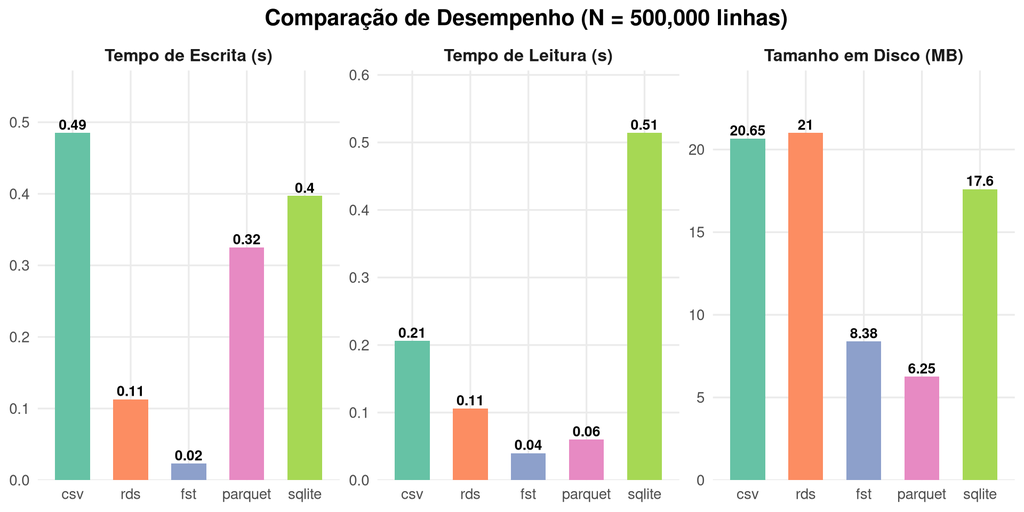

# Big Data no R

## Introdução

> O R carrega todos os dados **diretamente na memória RAM** (*in-memory*).
- Quando o tamanho dos dados excede a RAM disponível, o computador trava (ou desliga sozinho).
- Na prática, raramente precisamos de todos os dados brutos de uma vez: apenas colunas, filtros ou agregações específicas, o que permite processamento mais eficiente.
- **Pacotes Recomendados:**
  - `arrow` ([Apache Arrow](https://arrow.apache.org/docs/r/)): manipulação de arquivos colunares (`.parquet`) e datasets particionados em disco
  - `duckdb`: motor SQL analítico e de altíssimo desempenho
  - `sparklyr` / `dbplyr`: delegação de processamento pesado para bancos de dados SQL remotos ou clusters Apache Spark.

## Exercícios

1. Crie um dataframe artificial utilizando o pacote `wakefield`, permitindo definir a quantidade de linhas, o número de colunas e diferentes tipos de variáveis (ex.: texto, numérico, fator, data, booleano):

```r
library(wakefield)

n_row <- 10000
df <- r_data_frame(
  n = n_row,
  id,
  age,
  sex
)
```

Exporte o dataframe resultante para cada um dos formatos destacados a seguir:

- csv
- rds

Qual dos formatos ocupou maior espaço em disco? Podes verificar o tamanho dos arquivos no Windows Explorer ou com a função `file.size()` no R.

2. Experimente modificar o código anterior alterando:
   - O número de linhas (ex.: `n = 1000000`);

   Como o tamanho do arquivo e o tempo de gravação/leitura de cada formato respondem a diferentes tipos e volumes de dados?
3. No material do livro (pacote `afedR3`) existe um arquivo de dados chamado `CH08_some-stocks-SP500.csv`. Usando a função `afedR3::data_path`, utilize a função `readr::read_csv` para carregar o seu conteúdo. Utilize a função `glimpse` para verificar o conteúdo dos dados importados. Quantas colunas e qual o nome de cada coluna da tabela?
4. Na página da CVM é possível obter informações de todas as empresas atualmente listadas na bolsa em um arquivo disponível no link https://dados.cvm.gov.br/dados/CIA_ABERTA/CAD/DADOS/cad_cia_aberta.csv. Utilizando o R, baixe o arquivo em seu computador, importe os dados diretamente usando `readr::read_csv` (a função importa diretamente de arquivos compactados, sem necessidade de descompactação explícita). Quantas empresas fazem parte da bolsa atualmente (verifique o número de linhas do dataframe com a função `nrow`)?

# Referências

Perlin, Marcelo S. 2023. *afedR3: Data and Functions for Third Edition of Book "Analyzing Financial and Economical Data with r"*. https://github.com/msperlin/afedR3/.